# Welter et al. 2021 R notebook

## Moraxellaceae family analysis

```r
setwd("masterfolder/Moraxellaceae_family_analysis/")
```

```
The working directory was changed to /Users/dwelter/ownCloud/Psychrobacter/Data_Analysis/PANX/masterfolder/Moraxellaceae_family_analysis inside a notebook chunk. The working directory will be reset when the chunk is finished running. Use the knitr root.dir option in the setup chunk to change the the…
```

```r
#Import files
Moraxellaceae_tree = read.tree("Moraxellaceae_tree_ladderized.nwk")
Moraxellaceae_genome_summary = read.delim("Moraxellaceae_genome_characteristics.txt", stringsAsFactors = FALSE)
Moraxellaceae_isolation_info = read.delim("Moraxellaceae_isolation_information.txt", stringsAsFactors = F)
Moraxellaceae_genematrix = read.delim("Moraxellaceae_gene_presence_absence_binary_matrix.txt", stringsAsFactors = F, row.names = 1)
Moraxellaceae_genecluster_cogcats = read.delim("Moraxellaceae_geneclusters_COG_annotations.txt", stringsAsFactors = F)
```

# Figure 1 phylogeny

Gene presence/absence information obtained by PanX and PanX post-processing. The following code produces a gene presence-absence PCoA, which is used in Figures 1 and 2.

```r
Morax_isolation = as.data.frame(Moraxellaceae_isolation_info[,4])
rownames(Morax_isolation) = Moraxellaceae_isolation_info$strain

Morax_jacc_sim_gpa = vegan::vegdist(Moraxellaceae_genematrix, method = 'jaccard')
Morax_PCOA_cmdscale = cmdscale(Morax_jacc_sim_gpa, k = 3)
Morax_PCOA_points = as.data.frame(Morax_PCOA_cmdscale)
Morax_PCOA_points$strainID = rownames(Morax_PCOA_points)
#stats on genomic characteristics
kruskal.test(Genome.Length ~ genus, data = Moraxellaceae_genome_summary)
```

```
    Kruskal-Wallis rank sum test

data:  Genome.Length by genus
Kruskal-Wallis chi-squared = 34.021, df = 2, p-value = 4.097e-08
```

```r
pairwise.wilcox.test(Moraxellaceae_genome_summary$Genome.Length, Moraxellaceae_genome_summary$genus,
                     p.adjust.method = "BH")
```

```
    Pairwise comparisons using Wilcoxon rank sum test

data:  Moraxellaceae_genome_summary$Genome.Length and Moraxellaceae_genome_summary$genus

              Acinetobacter Moraxella
Moraxella     4.6e-09       -
Psychrobacter 0.011         7.9e-07

P value adjustment method: BH
```

```r
kruskal.test(Coding.density ~ genus, data = Moraxellaceae_genome_summary)
```

```
    Kruskal-Wallis rank sum test

data:  Coding.density by genus
Kruskal-Wallis chi-squared = 26.185, df = 2, p-value = 2.06e-06
```

```r
pairwise.wilcox.test(Moraxellaceae_genome_summary$Coding.density, Moraxellaceae_genome_summary$genus,
                     p.adjust.method = "BH")
```

```
cannot compute exact p-value with tiescannot compute exact p-value with tiescannot compute exact p-value with ties
```

```
    Pairwise comparisons using Wilcoxon rank sum test

data:  Moraxellaceae_genome_summary$Coding.density and Moraxellaceae_genome_summary$genus

              Acinetobacter Moraxella
Moraxella     0.94          -
Psychrobacter 1.3e-05       1.3e-05

P value adjustment method: BH
```

```r
Moraxellaceae_matrixforheatmap = left_join(Moraxellaceae_genome_summary[,c(1:2,4)], Morax_PCOA_points[,c(1,4)])
colnames(Moraxellaceae_matrixforheatmap)[4] = "PCoA_Dim1"
rownames(Moraxellaceae_matrixforheatmap) = Moraxellaceae_matrixforheatmap$strainID
Moraxellaceae_matrixforheatmap = Moraxellaceae_matrixforheatmap %>%
  select(Genome.Length, PCoA_Dim1, Coding.density)
Moraxellaceae_scaled_matrixforheatmap = apply(Moraxellaceae_matrixforheatmap, 2, FUN = function(X) (X - min(X))/diff(range(X)))
```

Now to export the data into an iTOL annotation file... The following functions do so.

```r
itol_colorstrip(df = Morax_isolation, dataset_label = "Isolation_Source",
                out_file = "Moraxellaceae_itol_colorstrip_isolation.txt")
```

```
File written: Moraxellaceae_itol_colorstrip_isolation.txt
```

```r
itol_heatmap(df = Moraxellaceae_scaled_matrixforheatmap, dataset_label = "Genome_Characteristics",
             color_scheme = "bw", out_file = "Moraxellaceae_itol_heatmap_genome_characteristics.txt")
```

```
File written: Moraxellaceae_itol_heatmap_genome_characteristics.txt
```

The default values for the colorstrip file are rainbow. I manually changed them to values from the "viridis" color scheme, such that isolation source colors would match across all figures.

The default "BW" color scheme assigns white as the color for the lowest value, black as a mid value, and gray as the highest value. I changed the text file manually so that black was the highest value.

# Figure 1 B/C (gene presence/absence PCoA)

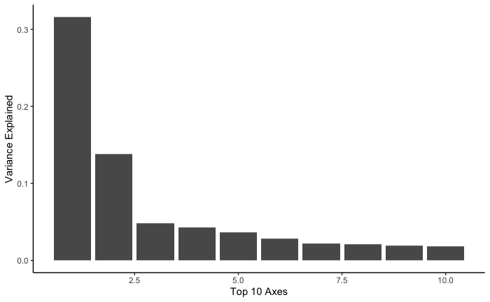

```r
#cumulative variance easier to look at with output of pcoa rather than cmdscale
Morax_PCOA_pcoa = pcoa(Morax_jacc_sim_gpa)
Morax_PCOA_pcoa_eig = as.data.frame(Morax_PCOA_pcoa$values$Relative_eig)
colnames(Morax_PCOA_pcoa_eig) = "variance"
Morax_PCOA_pcoa_eig$axes = rownames(Morax_PCOA_pcoa_eig)
Morax_PCOA_pcoa_eig$axes = as.numeric(Morax_PCOA_pcoa_eig$axes)
ggplot(data = Morax_PCOA_pcoa_eig[1:10,], aes(x = axes, y = variance)) + geom_bar(stat = 'identity') +
  theme_classic() + xlab("Top 10 Axes") + ylab("Variance Explained")
```

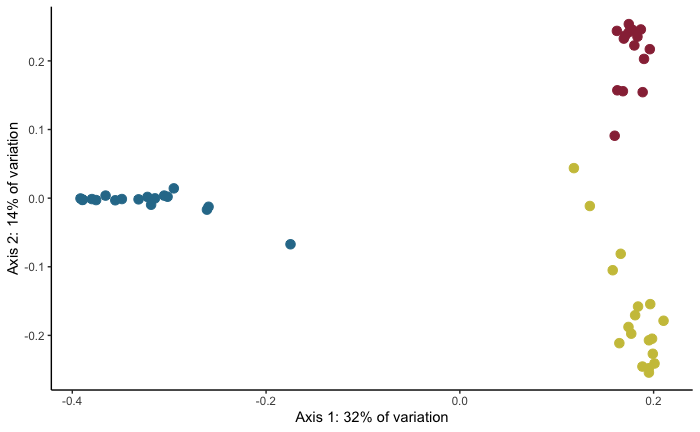

```r
#but envfit works more easily with cmdscale
#envfit contribution of individual genes
Morax_PCOA_points = left_join(Morax_PCOA_points, Moraxellaceae_genome_summary[,c(1,14)])
#Morax_PCOA_genefit = envfit(ord = Morax_PCOA_cmdscale, Moraxellaceae_genematrix, perm = 1000) #not recommended to run on personal computer!
#saveRDS(Morax_PCOA_genefit, file = "Moraxellaceae_genepresenceabsence_envfit.RDS")
#envfit contribution of genes collapsed by COG categories
cogcat = as.data.frame(table(Moraxellaceae_genecluster_cogcats$strain, Moraxellaceae_genecluster_cogcats$COG_cat))
colnames(cogcat) = c("strain", "COG_cat", "frequency")
cogcatspread = cogcat %>% spread(COG_cat, frequency)
Morax_PCOA_COGfit = envfit(ord = Morax_PCOA_cmdscale, cogcatspread, perm = 1000)
Morax_COGfit_coord_cont = as.data.frame(scores(Morax_PCOA_COGfit, "vectors")) * ordiArrowMul(Morax_PCOA_COGfit) * 0.5
#otherwise, the arrows will be too long to fit inside the subsequent plot...
Morax_COG_datascores = as.data.frame(scores(Morax_PCOA_cmdscale))
Morax_COG_datascores$strain = rownames(Moraxellaceae_genematrix)
Morax_COG_datascores = left_join(Morax_COG_datascores, Moraxellaceae_isolation_info[,c(1,8)])
#Table S5 r^2 values and p-values, in case you are interested...
table_S2_m = cbind(Morax_PCOA_COGfit$vectors$r, Morax_PCOA_COGfit$vectors$pvals)
table_S2_m = as.data.frame(table_S2_m)
colnames(table_S2_m) = c("moraxellaceae_r^2", "moraxellaceae_p-value")
table_S2_m$p.adjust = p.adjust(table_S2_m$`moraxellaceae_p-value`, method = "BH")
tables5 = round(table_S2_m, digits = 3)
write.table(table_S2_m, "table_S2_m.txt", sep = '\t') #needs to be in Excel table for inclusion as supplementary table in journal
biplot_A12 = ggplot(data = Morax_COG_datascores, aes(x = Dim1, y = Dim2)) +
  geom_point(data = Morax_COG_datascores, aes(colour = Genus), size = 3) +
  scale_color_manual(values = c("#2d7a99", "#ccc248", "#992f44")) +
  theme_classic() + xlab("Axis 1: 32% of variation") + ylab("Axis 2: 14% of variation") +
  theme_classic() + theme(legend.position = "none")
biplot_A12
```

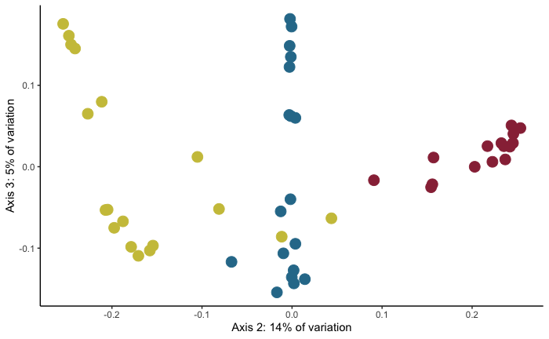

```r
biplot_A23 = ggplot(data = Morax_PCOA_points, aes(x = V2, y = V3, size = 5, color = genus)) + geom_point() +
  theme_classic() + xlab("Axis 2: 14% of variation") + ylab("Axis 3: 5% of variation") +
  scale_color_manual(values = c("#2d7a99", "#ccc248", "#992f44")) +
  theme(legend.position = "none")
biplot_A23
```

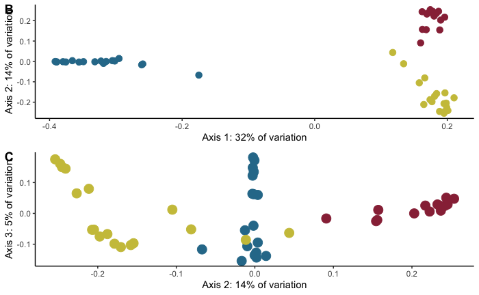

```r
ggarrange(biplot_A12, biplot_A23, ncol = 1, labels = c("B", "C"), align = 'hv')
```

I changed the colors of the vectors in Fig2A to reflect the p and r^2 values manually in Illustrator.

# Figure 2

```r
kruskal.test(sp_nov_min ~ Genus, data = Moraxellaceae_isolation_info)
```

```
    Kruskal-Wallis rank sum test

data:  sp_nov_min by Genus
Kruskal-Wallis chi-squared = 32.14, df = 3, p-value = 4.889e-07
```

```r
pairwise.wilcox.test(Moraxellaceae_isolation_info$sp_nov_min, Moraxellaceae_isolation_info$Genus, p.adjust.method = "BH")
```

```
cannot compute exact p-value with tiescannot compute exact p-value with tiescannot compute exact p-value with tiescannot compute exact p-value with tiescannot compute exact p-value with tiescannot compute exact p-value with ties
```

```
    Pairwise comparisons using Wilcoxon rank sum test

data:  Moraxellaceae_isolation_info$sp_nov_min and Moraxellaceae_isolation_info$Genus

                      Acinetobacter Moraxella
Acinetobacter 0.19553 -             -
Moraxella     0.51090 0.01029       -
Psychrobacter 0.15239 0.00019       5e-06

P value adjustment method: BH
```

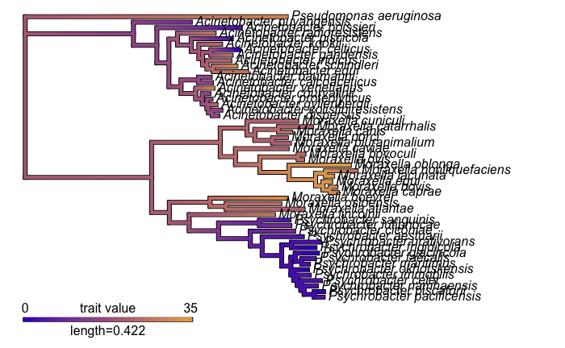

```r
rownames(Moraxellaceae_isolation_info) = Moraxellaceae_isolation_info$strain
min_temp <- setNames(Moraxellaceae_isolation_info$sp_nov_min, rownames(Moraxellaceae_isolation_info))
mintemp.map <- contMap(Moraxellaceae_tree, min_temp, plot = F)
## change to blue -> red
#library(scales)
#library(unikn)
#blues = colorRampPalette(c("#FFCE00", "#381FC6"), bias = 1, space = "Lab")
#show_col(blues(22))
#seecol(blues(22))
n <-length(mintemp.map$cols)
mintemp.map$cols[1:n]<-colorRampPalette(c("#381FC5", "#E7AB50"), space="Lab")(n)
mintemp.p = plot(mintemp.map)
```

```r
mintemp.p
```

```
[1] 0
```

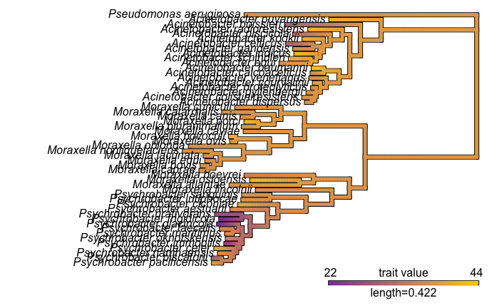

```r
max_temp <- setNames(Moraxellaceae_isolation_info$sp_nov_max, rownames(Moraxellaceae_isolation_info))
maxtemp.map <- contMap(Moraxellaceae_tree, max_temp, plot = F)
maxtemp.map$cols[1:n]<-colorRampPalette(c("#8946A8", "#FFCD00"), space="Lab")(n)
#plot(maxtemp.map)
maxtemp.p = plot(maxtemp.map, lwd = 5, direction = "leftwards")
```

```r
maxtemp.p
```

```
[1] 0
```

It's rather difficult to manipulate these plots directly in R, so I did post-processing directly in Illustrator.

# Psychrobacter analysis

```r
setwd("masterfolder/Psychrobacter_genus_analysis")
```

```
The working directory was changed to /Users/dwelter/ownCloud/Psychrobacter/Data_Analysis/PANX/masterfolder/Psychrobacter_genus_analysis inside a notebook chunk. The working directory will be reset when the chunk is finished running. Use the knitr root.dir option in the setup chunk to change the the …
```

```r
library(ggmap)
library(maptools)
library(maps)
library(viridis)
library(treeWAS)
#Import files
psych_strain_collection = read.delim("Psychrobacter_straininfo_mastertable.txt", stringsAsFactors = F)
psychrobacter_phenotype_growthbin = read.delim("psychrobacter_growthbin.txt", stringsAsFactors = F)
psychrobacter_PCAT = read.delim("Psych_20201016_PCAT.txt", stringsAsFactors = F)
psychrobacter_pangenome_annotated = read.delim("Psych_20201016_eggnog_clusters_annotations.txt", stringsAsFactors = F)
multicog_geneclusters = read.delim("multiCOG_genes_unseparated.txt", stringsAsFactors = F)
#essentially took psychrobacter_pangenome_annotated, and split $COG_cat by commas to separate out the genes that have multiple cog categories
psychrobacter_pangenome_presenceabsence = read.delim("psych_20201016_nodash_gpa.txt", stringsAsFactors = F)
genematrix = read.delim("genematrix_for_treewas_fixeddashes.txt")
psychrobacter_pseudogene_predictions = read.delim("pseudogene_predictions_from_DFAST.txt", stringsAsFactors = F)
psychrobacter_genome_summaries = read.delim("psychrobacter_genome_summary_statistics.txt", stringsAsFactors = F)
bile = read.delim("bileres.txt", stringsAsFactors = F)
P.tree = read.tree("Psychfinal_outgroupMoraxlincolnii.nwk")
P.tree = root(P.tree, outgroup = 'Moraxella_lincolnii', resolve.root = TRUE)
P.tree.noout = drop.tip(P.tree, "Moraxella_lincolnii")
```

# Figure 3

```r
#iTOL color strip for isolation source
psych_isolation_source = as.data.frame(psych_strain_collection$source)
rownames(psych_isolation_source) = psych_strain_collection$propername
itol_colorstrip(df = psych_isolation_source, dataset_label = "Isolation_Source",
                out_file = "itol_isolation_colorstrip.txt")
```

```
File written: itol_isolation_colorstrip.txt
```

```r
#calculating growth probabilities for every individual condition
growth_prob_agg = aggregate(psychrobacter_phenotype_growthbin$GrowthBin, by = list(psychrobacter_phenotype_growthbin$propername, psychrobacter_phenotype_growthbin$medium, psychrobacter_phenotype_growthbin$salt, psychrobacter_phenotype_growthbin$temperature), FUN = median)
growth_prob_agg = growth_prob_agg %>% select(Group.1, Group.2, Group.3, Group.4, x)
colnames(growth_prob_agg) = c("strainID", "medium", "salt", "temperature", "growthbin")
#calculating growth probabilities aggregated by medium
growth_prob_medium = aggregate(growth_prob_agg$growthbin, by = list(growth_prob_agg$strainID, growth_prob_agg$medium), FUN = mean)
growth_prob_medium = growth_prob_medium %>% select(Group.1, Group.2, x)
colnames(growth_prob_medium) = c("strainID", "medium", "growthbin")
growth_prob_medium = growth_prob_medium %>%
  spread(medium, growthbin)
colnames(growth_prob_medium) = c("strainID", "LB", "MM")
rownames(growth_prob_medium) = growth_prob_medium$strainID
growth_prob_medium_round = growth_prob_medium
growth_prob_medium_round$strainID = NULL
growth_prob_medium_round = round(growth_prob_medium_round, digits = 1) #makes the heatmap cleaner
itol_heatmap(df = growth_prob_medium_round, dataset_label = "medium",
             color_scheme = "bw", out_file = "itol_medium_growth_prob_heatmap.txt")
```

```
File written: itol_medium_growth_prob_heatmap.txt
```

```r
#manually changed mid color to #ECD797 and max color to #D0A215
#calculating growth probabilities aggregated by salt
growth_prob_salt = aggregate(growth_prob_agg$growthbin, by = list(growth_prob_agg$strainID, growth_prob_agg$salt), FUN = mean)
growth_prob_salt = growth_prob_salt %>% select(Group.1, Group.2, x)
colnames(growth_prob_salt) = c("strainID", "salt", "growthbin")
growth_prob_salt = growth_prob_salt %>%
  spread(salt, growthbin)
colnames(growth_prob_salt) = c("strainID", "0_perc", "2.5_perc", "5_perc", "10_perc")
rownames(growth_prob_salt) = growth_prob_salt$strainID
growth_prob_salt_round = growth_prob_salt
growth_prob_salt_round$strainID = NULL
growth_prob_salt_round = round(growth_prob_salt_round, digits = 1) #makes the heatmap cleaner
itol_heatmap(df = growth_prob_salt_round, dataset_label = "salt",
             color_scheme = "bw", out_file = "itol_salt_growth_prob_heatmap.txt")
```

```
File written: itol_salt_growth_prob_heatmap.txt
```

```r
#manually changed mid color to #9BD3E3 and max color to #2E9CBD
#calculating growth probabilities aggregated by temperature
growth_prob_temp = aggregate(growth_prob_agg$growthbin, by = list(growth_prob_agg$strainID, growth_prob_agg$temperature), FUN = mean)
growth_prob_temp = growth_prob_temp %>% select(Group.1, Group.2, x)
colnames(growth_prob_temp) = c("strainID", "temperature", "growthbin")
growth_prob_temp = growth_prob_temp %>%
  spread(temperature, growthbin)
rownames(growth_prob_temp) = growth_prob_temp$strainID
colnames(growth_prob_temp) = c("strainID", "4C", "25C", "37C")
growth_prob_temp_round = growth_prob_temp
growth_prob_temp_round$strainID = NULL
growth_prob_temp_round = round(growth_prob_temp_round, digits = 1) #makes the heatmap cleaner
itol_heatmap(df = growth_prob_temp_round, dataset_label = "temperature",
             color_scheme = "bw", out_file = "itol_temp_growth_prob_heatmap.txt")
```

```
File written: itol_temp_growth_prob_heatmap.txt
```

```r
#manually changed mid color to #B87676 and max color to #6E2020
bile = left_join(bile, psych_strain_collection[,c(3:4)])
bile_filt = bile %>% filter(is.na(propername) == F)
rownames(bile_filt) = bile_filt$propername
bile_filt = bile_filt %>% select(BSA)
bile_filt$BSA[bile_filt$BSA == 1] <- "resistant"
bile_filt$BSA[bile_filt$BSA == 0] <- "sensitive"
itol_colorstrip(df = bile_filt, dataset_label = "Bile Resistance",
                out_file = "itol_bile_colorstrip.txt")
```

```
File written: itol_bile_colorstrip.txt
```

```r
#manually change resistant color to #03222E and sensitive color to #A3C7B3
```

Then I defined ecotypes for the strains... FE or "flexible ecotype" for those with a non-zero growth probability at 37C, and RE or "restricted ecotype" for those with a zero growth probability at 37C.

```r
FEstrains = growth_prob_temp %>%
  filter(`37C` > 0) %>% rownames()
REstrains = psychrobacter_phenotype_growthbin %>%
  filter(!propername %in% FEstrains) %>% select(propername) %>%
  unlist() %>% unname() %>% unique()
ecotype = c(rep("FE", 26), rep("RE", 59))
ecotype = as.data.frame(ecotype)
strains = c(FEstrains, REstrains)
rownames(ecotype) = strains
ecotype$strainID = rownames(ecotype)
itol_colorstrip(df = ecotype, dataset_label = "Ecotype",
                out_file = "itol_ecotype_colorstrip.txt")
```

```
File written: itol_ecotype_colorstrip.txt
```

```r
#manually change colors: FE -> #FFCA45, RE -> #1F4589
```

```r
#ecotypes by isolation source
df = left_join(ecotype, growth_prob_medium)
df = left_join(df, growth_prob_salt)
df = left_join(df, growth_prob_temp)
colnames(df)[2] = "propername"
df = left_join(df, psych_strain_collection[,c(3,18)])
colnames(df)[2] = "strainID"
tmp <- df
tmp$source_simple = as.character(tmp$source_simple)
table(tmp$ecotype, tmp$source_simple)
```

```
     food marine other host terrestrial warm host
  FE    2      7          3           4        10
  RE    9     14         20          12         4
```

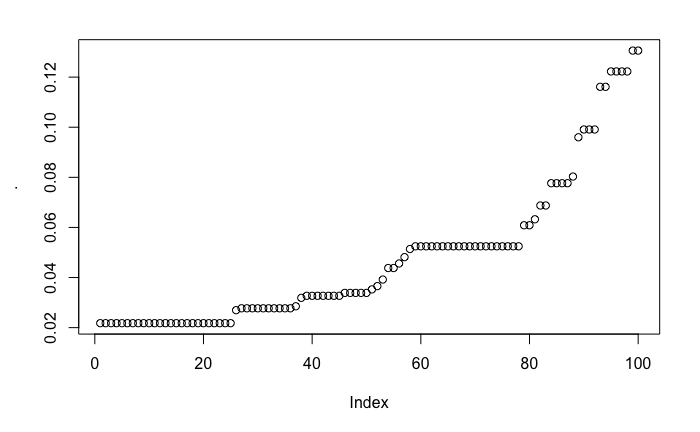

```r
library(caret)
chires <- list()
pval <- c()
for (i in 1:100){
    set.seed(i)
    t1 <- downSample(tmp, as.factor(tmp$source_simple))
    suppressWarnings(chires[[i]] <- chisq.test(x = t1$source_simple, y = t1$ecotype))
    pval <- c(pval, chires[[i]]$p.value)
}
padj <- p.adjust(pval, method = 'BH')
options(repr.plot.height=4, repr.plot.width=4)
padj %>% sort %>% plot
```

```r
#growth probability differences between the ecotypes
plist = c()
for (i in 3:11) {
  dummy = df[,c(i, 1)]
  dummytest = wilcox.test(dummy[,1] ~ dummy$ecotype)
  plist = c(plist, dummytest$p.value)
}
plist_adj = p.adjust(plist, method = "BH")
names(plist_adj) = c("LB", "MM", "0%", "2.5%", "5%", "10%", "4C", "25C", "37C")
plist_adj
```

```
          LB           MM           0%         2.5%           5%          10%           4C          25C          37C
7.075732e-08 7.713210e-01 1.489572e-02 2.686299e-05 1.489572e-02 9.878480e-01 8.851115e-01 7.713210e-01 2.700923e-18
```

```r
df$delta_medium = df$LB - df$MM
wilcox.test(df$delta_medium ~ df$ecotype)
```

```
    Wilcoxon rank sum test with continuity correction

data:  df$delta_medium by df$ecotype
W = 1132.5, p-value = 0.0004869
alternative hypothesis: true location shift is not equal to 0
```

```r
#testing some of these differences by phylogeny
set.seed(1)
LB = df$LB
eco = df$ecotype
names(LB) = names(eco) = df$strainID
P.tree.noout = drop.tip(P.tree, "Moraxella_lincolnii")
P.tree.branches = compute.brlen(P.tree.noout)
library(geiger)
aov.phylo(formula = LB~eco, phy = multi2di(P.tree.branches))
```

```
Analysis of Variance Table

Response: dat
          Df  Sum-Sq Mean-Sq F-value     Pr(>F) Pr(>F) given phy
group      1 0.77901 0.77901  43.404 3.8241e-09          0.01099 *
Residuals 83 1.48966 0.01795
---
Signif. codes:  0 ‘***’ 0.001 ‘**’ 0.01 ‘*’ 0.05 ‘.’ 0.1 ‘ ’ 1

Call:
lm(formula = dat ~ group)

Coefficients:
(Intercept)      groupRE
     0.7035      -0.2078
```

```r
zero = df$`0_perc`
names(zero) = df$strainID
aov.phylo(formula = zero~eco, phy = multi2di(P.tree.branches))
```

```
Analysis of Variance Table

Response: dat
          Df Sum-Sq Mean-Sq F-value    Pr(>F) Pr(>F) given phy
group      1 0.3450 0.34496  7.7623 0.0066089           0.3407
Residuals 83 3.6885 0.04444

Call:
lm(formula = dat ~ group)

Coefficients:
(Intercept)      groupRE
     0.6058      -0.1383
```

```r
twofive = df$`2.5_perc`
names(twofive) = df$strainID
aov.phylo(formula = twofive~eco, phy = multi2di(P.tree.branches))
```

```
Analysis of Variance Table

Response: dat
          Df  Sum-Sq Mean-Sq F-value     Pr(>F) Pr(>F) given phy
group      1 0.75456 0.75456  24.047 4.6091e-06          0.08092 .
Residuals 83 2.60443 0.03138
---
Signif. codes:  0 ‘***’ 0.001 ‘**’ 0.01 ‘*’ 0.05 ‘.’ 0.1 ‘ ’ 1

Call:
lm(formula = dat ~ group)

Coefficients:
(Intercept)      groupRE
     0.7115      -0.2045
```

```r
five = df$`5_perc`
names(five) = df$strainID
aov.phylo(formula = five~eco, phy = multi2di(P.tree.branches))
```

```
Analysis of Variance Table

Response: dat
          Df  Sum-Sq  Mean-Sq F-value    Pr(>F) Pr(>F) given phy
group      1 0.26891 0.268905  7.4734 0.0076519           0.3626
Residuals 83 2.98649 0.035982

Call:
lm(formula = dat ~ group)

Coefficients:
(Intercept)      groupRE
     0.5288      -0.1221
```

```r
pval <- c()
lamb <- c()
for (i in 3:11){
    trait <- unlist(df[,i]) #trait = growth proba in a condition (eg growth proba in LB)
    names(trait) <- df$strainID
    tmp <- phylosig(tree = P.tree, x = trait, method="lambda", test= TRUE)
    pval <- c(pval, tmp$P)
    lamb <- c(lamb, tmp$lambda)
}
```

[output not shown]

```r
names(pval) <- colnames(df)[3:11]
names(lamb) <- colnames(df)[3:11]
padj <- p.adjust(pval, method = 'BH')
tmp
```

```
Phylogenetic signal lambda : 0.97256
logL(lambda) : 81.6908
LR(lambda=0) : 143.853
P-value (based on LR test) : 3.82492e-33
```

```r
tmp <- which(padj > 0.05)
if (length(tmp) == 0){cat('All significant!')}
```

```
All significant!
```

```r
max(padj)
```

```
[1] 0.0009051341
```

```r
round(lamb, digits = 4) %>% sort
```

```
  5_perc       4C   0_perc  10_perc       LB 2.5_perc      25C       MM      37C
  0.7786   0.9060   0.9074   0.9115   0.9266   0.9291   0.9386   0.9603   0.9726
```

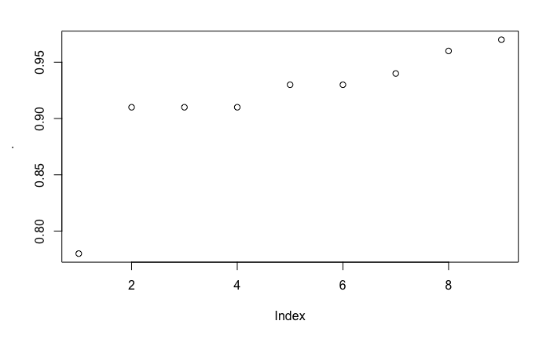

```r
options(repr.plot.height=4, repr.plot.width=4)
round(lamb, digits = 2) %>% sort %>% plot
```

```r
trait <- df %>% subset(ecotype == 'FE', select = '37C') %>% unlist
names(trait) <- df %>% subset(ecotype == 'FE', select = 'strainID') %>% unlist
phylosig(tree = P.tree, x = trait, method="lambda", test= TRUE)
```

```
[1] "some species in tree are missing from x , dropping missing taxa from the tree"

Phylogenetic signal lambda : 0.885323
logL(lambda) : 11.7639
LR(lambda=0) : 16.7981
P-value (based on LR test) : 4.15745e-05
```

# Pan-genome wide association study

```r
ecotype_hits
```

```
[1] "GC00000020_6"       "GC00001343_6"       "GC00001837_r1_r1_1" "GC00001839_r1_1"
```

# Figure 4A

As with the Moraxellaceae gene presence-absence matrix, the Psychrobacter gene presence-absence matrix was generated by processing data from PanX.

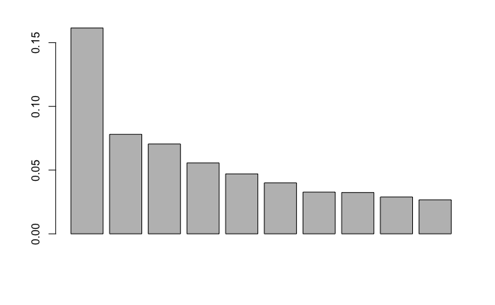

```r
#visualize gene presence/absence with PCoA
psych_jacc_sim_PBPD_gpa = vegan::vegdist(genematrix_binary_t, method = 'jaccard')
#this takes FOREVER to run for some reason
#get relative contributions of axes via pcoa function
psych_PCOA_pcoa = pcoa(psych_jacc_sim_PBPD_gpa)
barplot(psych_PCOA_pcoa$values$Relative_eig[1:10]) #variance of first 10 axes
```

```r
psych_PCOA_pcoa$values$Relative_eig[1:10]
```

```
 [1] 0.16148404 0.07806123 0.07049873 0.05560508 0.04703421 0.04000924 0.03273657 0.03239061 0.02890749 0.02668125
```

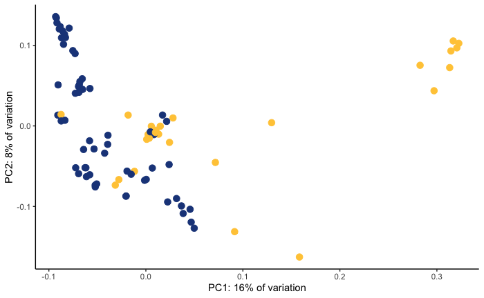

```r
#do envfit analysis with cmdscale
PBvPD_PCOA_cmdscale = cmdscale(psych_jacc_sim_PBPD_gpa)
psych_gpa_pcoa = as.data.frame(vegan::scores(PBvPD_PCOA_cmdscale))
psych_gpa_pcoa$strainID = rownames(psych_gpa_pcoa)
psych_gpa_pcoa = left_join(psych_gpa_pcoa, ecotype)
(gpa_pcoa_envfit = ggplot(data = psych_gpa_pcoa, aes(x = Dim1, y = Dim2)) +
  geom_point(data = psych_gpa_pcoa, aes(colour = ecotype), size = 3) +
  scale_color_manual(values = c("#FFCA45", "#1F4589"))  +
  xlab("PC1: 16% of variation") + ylab("PC2: 8% of variation") +
  theme_classic() + theme(legend.position = "none"))
```

```r
#this part was removed from the mSystems manuscript
psych_cogcats = as.data.frame(table(psychrobacter_geneclusters_COGS$strain, psychrobacter_geneclusters_COGS$COG_cat))
```

```
Error in table(psychrobacter_geneclusters_COGS$strain, psychrobacter_geneclusters_COGS$COG_cat) :
  object 'psychrobacter_geneclusters_COGS' not found
```

By plotting with individual labels, you see that the strains off to the right and up by themselves are the PB-clade strains.

# Figure 4B

Genome architecture information

```r
#need to define genes as being either 'core', 'shell', or 'cloud'...
#so, need to get the number of isolates each gene appears in
core_info = as.data.frame(rowSums(genematrix_binary))
colnames(core_info)[1] = "num_isolates"
core_info$geneCluster = rownames(core_info)
core_info$pancat = NA
core_info$pancat[core_info$num_isolates >= 77] <- "core"
core_info$pancat[core_info$num_isolates <= 76 & core_info$num_isolates >= 2] <- "shell"
core_info$pancat[core_info$num_isolates == 1] <- "cloud"
#now, assigning "pangenome-categories" to every gene sequence in every isolate, so that we can see how many of each type of gene each strain carries
core_info_per_genome = left_join(psychrobacter_PCAT[,2:3], core_info[,2:3])
core_info_per_genome_summary = as.data.frame(table(core_info_per_genome$strainID, core_info_per_genome$pancat))
colnames(core_info_per_genome_summary) = c("strainID", "pancat", "frequency")
aggregate(core_info_per_genome_summary$frequency, by = list(core_info_per_genome_summary$pancat), FUN = mean)
```

```
  Group.1          x
1   cloud   70.36471
2    core 1598.12941
3   shell 1004.58824
```

```r
core_info_per_genome_summary$pancat = factor(core_info_per_genome_summary$pancat, levels = c("core", "shell", "cloud"))
core_info_per_genome_summary = left_join(core_info_per_genome_summary, ecotype)
core_info_per_genome_summary$ecotype[core_info_per_genome_summary$strainID == "P_sp_IAM12030_72-O-c"] <- "RE"
numberofgenes = as.data.frame(table(psychrobacter_PCAT$strainID))
colnames(numberofgenes) = c("strainID", "GeneNumber")
#some stats on the pangenome structure
#difference in number of core genes per genome
stats_core = core_info_per_genome_summary %>% filter(pancat == "core")
wilcox.test(frequency ~ ecotype, data = stats_core)
```

```
    Wilcoxon rank sum test with continuity correction

data:  frequency by ecotype
W = 531.5, p-value = 0.02497
alternative hypothesis: true location shift is not equal to 0
```

```r
aggregate(stats_core$frequency, by = list(stats_core$ecotype), FUN = mean)
```

```
  Group.1        x
1      FE 1569.077
2      RE 1610.932
```

```r
#difference in number of shell genes per genome
stats_shell = core_info_per_genome_summary %>% filter(pancat == "shell")
wilcox.test(frequency ~ ecotype, data = stats_shell)
```

```
    Wilcoxon rank sum test with continuity correction

data:  frequency by ecotype
W = 462, p-value = 0.003683
alternative hypothesis: true location shift is not equal to 0
```

```r
aggregate(stats_shell$frequency, by = list(stats_shell$ecotype), FUN = mean)
```

```
  Group.1         x
1      FE  924.1923
2      RE 1040.0169
```

```r
eco = factor(eco, levels = c("FE", "RE"))
shellg = stats_shell$frequency
names(shellg) = stats_shell$strainID
set.seed(1)
aov.phylo(formula = shellg~eco, phy = multi2di(P.tree.noout))
```

```
The following tips were not found in 'data' and were dropped from 'phy':
    P_sp_IAM12030-72-O-c
```

```
Analysis of Variance Table

Response: dat
          Df  Sum-Sq Mean-Sq F-value    Pr(>F) Pr(>F) given phy
group      1  240122  240122   8.498 0.0045828           0.3826
Residuals 82 2317020   28256

Call:
lm(formula = dat ~ group)

Coefficients:
(Intercept)      groupRE
      924.2        115.7
```

```r
#difference in number of cloud genes per genome
stats_cloud = core_info_per_genome_summary %>% filter(pancat == "cloud")
wilcox.test(frequency ~ ecotype, data = stats_cloud)
```

```
    Wilcoxon rank sum test with continuity correction

data:  frequency by ecotype
W = 1014, p-value = 0.01871
alternative hypothesis: true location shift is not equal to 0
```

```r
aggregate(stats_cloud$frequency, by = list(stats_cloud$ecotype), FUN = mean)
```

```
  Group.1         x
1      FE 128.65385
2      RE  44.67797
```

```r
cloudg = stats_cloud$frequency
names(cloudg) = stats_cloud$strainID
set.seed(1)
aov.phylo(formula = cloudg~eco, phy = multi2di(P.tree.noout))
```

```
The following tips were not found in 'data' and were dropped from 'phy':
    P_sp_IAM12030-72-O-c
```

```
Analysis of Variance Table

Response: dat
          Df Sum-Sq Mean-Sq F-value     Pr(>F) Pr(>F) given phy
group      1 124493  124493  14.146 0.00031621           0.2328
Residuals 82 721656    8801

Call:
lm(formula = dat ~ group)

Coefficients:
(Intercept)      groupRE
     128.65       -83.27
```

```r
#difference in total number of genes
totg = numberofgenes$GeneNumber
names(totg) = numberofgenes$strainID
set.seed(1)
aov.phylo(formula = totg~eco, phy = multi2di(P.tree.noout))
```

```
The following tips were not found in 'data' and were dropped from 'phy':
    P_sp_IAM12030-72-O-c
```

```
Analysis of Variance Table

Response: dat
          Df  Sum-Sq Mean-Sq F-value   Pr(>F) Pr(>F) given phy
group      1   98695   98695   2.895 0.092641           0.6304
Residuals 82 2795470   34091

Call:
lm(formula = dat ~ group)

Coefficients:
(Intercept)      groupRE
    2621.92        74.15
```

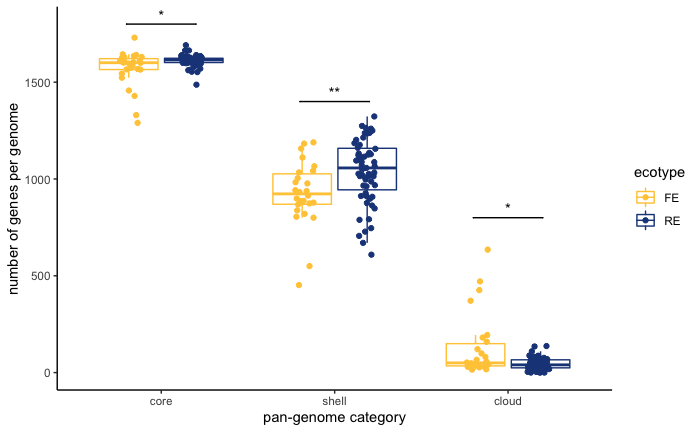

```r
(panstr = ggplot(data = core_info_per_genome_summary, aes(x = pancat, y = frequency)) +
  geom_point(aes(color = ecotype), position = position_jitterdodge(dodge.width = 0.7, jitter.width = 0.25)) +
  scale_color_manual(values = c("#FFCA45", "#1F4589")) +
  geom_boxplot(aes(color = ecotype), outlier.shape = NA, alpha = 0) +
  geom_signif(y_position = c(1800, 1400, 800), xmin = c(0.8, 1.8, 2.8), xmax = c(1.2, 2.2, 3.2), annotation = c("*", "**", "*"), tip_length = 0) +
  theme_classic() +
  xlab("pan-genome category") + ylab("number of genes per genome"))
```

# Figure 4C COG category comparisons

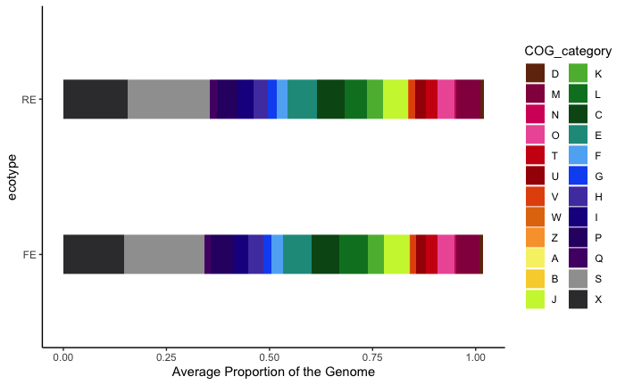

```r
#examination of COG categories between FE and RE strains
####COG by ecotypes####
psych_PCAT_annotated = left_join(psychrobacter_PCAT, ecotype)
COGS = psychrobacter_pangenome_annotated %>%
  select(geneCluster, COG.cat)
COGS$COG.cat[COGS$COG.cat == ''] <- 'X'
psych_PCAT_annotated = left_join(psych_PCAT_annotated, COGS)
psych_PCAT_annotated$COG.cat[psych_PCAT_annotated$COG.cat == ''] <- 'X'
psych_PCAT_annotated$COG.cat[is.na(psych_PCAT_annotated$COG.cat)] <- 'X'
#COGs_by_genome = as.data.frame(table(psych_PCAT_annotated$strainID, psych_PCAT_annotated$COG.cat))
#colnames(COGs_by_genome) = c("strainID", "COG_category", "frequency")
#write.table(COGs_by_genome, "COG_category_summary_by_genome.txt", row.names = F, sep = '\t')
#have to account for proteins that have multiple COG categories...
#separate the categories using excel's text to columns, then bring back to R...
#COGs_by_genome = read.delim("COG_category_summary_by_genome.txt", stringsAsFactors = F)
multiCOG_genes = psych_PCAT_annotated %>% select(geneCluster, strainID, COG.cat)
#write.table(multiCOG_genes, "multiCOG_genes_unseparated.txt", row.names = F, sep = '\t')
COG_single_cats = multicog_geneclusters %>%
  filter(COG_2 == "") #%>% select(strainID, COG_1, frequency)
COG_multi_cats = anti_join(multicog_geneclusters, COG_single_cats)
COG_multi_cats = COG_multi_cats
#just realized that this does not have every COG cat for every strain, for example there is no COG CAT "B" for frigidicola_056...
#will have to make a new data frame to populate from scratch
COG_multi_cats_separated = data.frame()
for(i in 1:nrow(COG_multi_cats)) {
  genec = COG_multi_cats[i,1]
  strain = COG_multi_cats[i,2]
  COG1 = COG_multi_cats[i,3]
  dummy1 = c(genec, strain, COG1)
  COG_multi_cats_separated = rbind.data.frame(COG_multi_cats_separated, as.character(dummy1), stringsAsFactors = F)
  COG2 = COG_multi_cats[i,4]
  dummy2 = c(genec,strain, COG2)
  COG_multi_cats_separated = rbind.data.frame(COG_multi_cats_separated, as.character(dummy2), stringsAsFactors = F)
  COG3 = COG_multi_cats[i,5]
  if (COG3 != ""){
    dummy3 = c(genec,strain, COG3)
    COG_multi_cats_separated = rbind.data.frame(COG_multi_cats_separated, as.character(dummy3), stringsAsFactors = F)
  }
  COG4 = COG_multi_cats[i,6]
  if (COG4 != ""){
    dummy4 = c(genec, strain, COG1)
    COG_multi_cats_separated = rbind.data.frame(COG_multi_cats_separated, as.character(dummy4), stringsAsFactors = F)
  }
}
colnames(COG_multi_cats_separated) = c("geneCluster", "strainID", "COG_category")
COG_single_cats = COG_single_cats %>%
  select(geneCluster, strainID, COG_1)
colnames(COG_single_cats)[3] = "COG_category"
final_corrected_COGS = rbind(COG_single_cats, COG_multi_cats_separated)
final_corrected_COGS_freq = as.data.frame(table(final_corrected_COGS$strainID, final_corrected_COGS$COG_category))
colnames(final_corrected_COGS_freq) = c("strainID", "COG_category", "frequency")
final_corrected_COGS_freq = left_join(final_corrected_COGS_freq, ecotype)
final_corrected_COGS_freq = left_join(final_corrected_COGS_freq, numberofgenes)
final_corrected_COGS_freq$finalCOGproportion = final_corrected_COGS_freq$frequency/final_corrected_COGS_freq$GeneNumber
write.table(final_corrected_COGS, "final_COGs_per_strain_corrected_for_multiCOG_genes.txt", sep = '\t', row.names = F)
av_ecotype_cogs = aggregate(final_corrected_COGS_freq$finalCOGproportion, by =
                              list(ecotype = final_corrected_COGS_freq$ecotype, COG_category=final_corrected_COGS_freq$COG_category),
                            FUN = mean)
colnames(av_ecotype_cogs)[3] = 'COG_prop'
av_ecotype_cogs$COG_category = factor(av_ecotype_cogs$COG_category, levels = c("D", "M", "N", "O", "T", "U", "V", "W", "Z",
                                                                               "A", "B","J", "K", "L",
                                                                               "C", "E", "F", "G", "H", "I", "P", "Q",
                                                                               "S", "X"))
cols = c("#72300C", "#93074D", "#D60D69", "#ED5FA6", "#CE1B13", "#A50505",
         "#E5530A", "#E2770C", "#F9A138", "#F7F072", "#F7D239", "#CCF43B",
         "#5BB73D", "#057F28", "#05541A", "#20998B", "#60B1F4", "#1458F2",
         "#5141AF", "#1F048E", "#310872", "#520775", "#9F9FA0", "#39383A")
COGSbyecotype.p = ggplot(data = av_ecotype_cogs, aes(y = ecotype, x = COG_prop, fill = COG_category)) +
  geom_bar(stat = 'identity', position = "stack", width = 0.25) + scale_fill_manual(values = cols) +
  theme_classic() +
  xlab("Ecotype") + xlab("Average Proportion of the Genome")
COGSbyecotype.p
```

```r
#bars are higher than 1 because of genes with multiple COG categories...
```

examining COG contributions to separation on gene presence/absence PCOA... used only in supplemental file

```r
#this part was removed from the mSystems manuscript
psych_cogcats = as.data.frame(table(final_corrected_COGS_freq$strainID, final_corrected_COGS_freq$COG_category))
colnames(psych_cogcats) = c("strainID", "COG_cat", "frequency")
psych_cogcatspread = psych_cogcats %>% spread(COG_cat, frequency)
psych_PBvPD_COG_fit = envfit(ord = PBvPD_PCOA_cmdscale, psych_cogcatspread, perm = 1000)
```

[output not shown]

```r
psych_coord_cont = as.data.frame(scores(psych_PBvPD_COG_fit, "vectors")) * ordiArrowMul(psych_PBvPD_COG_fit)
```

```
no non-missing arguments to min; returning Inf
```

```r
#for some reason, running this code inside this R notebook makes the arrow size goofy... the r^2 and p-values are still the same, but the arrows in the ggplot look strange. play around with it to make the plot look nice...
psych_cog_envfit_scores = as.data.frame(scores(PBvPD_PCOA_cmdscale))
psych_cog_envfit_scores$strainID = rownames(genematrix_binary_t)
psych_cog_envfit_scores = left_join(psych_cog_envfit_scores, psych_strain_collection[,c(5,3)])
psych_cog_envfit_scores$strainID = NULL
colnames(psych_cog_envfit_scores)[3] = 'strainID'
psych_cog_envfit_scores = left_join(psych_cog_envfit_scores, ecotype)
table_S2_p = cbind(psych_PBvPD_COG_fit$vectors$r, psych_PBvPD_COG_fit$vectors$pvals)
table_S2_p = as.data.frame(table_S2_p)
colnames(table_S2_p) = c("psych_r^2", "psych_p-value")
table_S2_p$p.adjust = p.adjust(tables7$`psych_p-value`, method = "BH")
```

```
Error in p.adjust(tables7$`psych_p-value`, method = "BH") :
  object 'tables7' not found
```

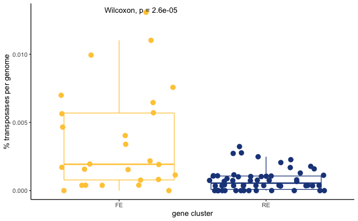

```r
#Figure 4D
#looking at transposons in particular
#make list of transposases from annotations
transposase_list = psychrobacter_pangenome_annotated %>%
  filter(str_detect(eggNOG.annot, "transposase")) %>%
  select(geneCluster) %>% unlist() %>% unname()
#calculate the copy numbers for each of the transposases in the list
gpa = psychrobacter_pangenome_presenceabsence[,c(1,10:ncol(psychrobacter_pangenome_presenceabsence))]
rownames(gpa) = gpa$geneCluster
gpa = gpa %>% filter(geneCluster %in% transposase_list)
gpa_nareplace = apply(gpa,  2,  function(x) gsub("^$|^ $",  NA,  x)) #replace empty cells with NA
gpa_nareplace = as.data.frame(gpa_nareplace)
gpa_nareplace = gpa_nareplace %>%
  mutate_if(is.factor, as.character)
rownames(gpa_nareplace) = rownames(gpa)
gpa_numsequences = gpa_nareplace
for(i in 1:nrow(gpa_nareplace)) {
  for (j in 2:ncol(gpa_nareplace)) {
    cell = gpa_nareplace[i,j]
    num = str_count(cell, ",") + 1
    if (is.na(cell) == TRUE) {num = 0}
    gpa_numsequences[i,j] = num
  }
}
gpa_numsequences_t = t(gpa_numsequences[,2:ncol(gpa_numsequences)])
colnames(gpa_numsequences_t) = gpa_numsequences$geneCluster
gpa_numsequences_t = as.data.frame(gpa_numsequences_t)
gpa_numsequences_t[] <- lapply(gpa_numsequences_t, function(x) {
    if(is.factor(x)) as.numeric(as.character(x)) else x
})
cn_per_genome = rowSums(gpa_numsequences_t)
names(cn_per_genome) = rownames(gpa_numsequences_t)
cnpg = as.data.frame(cn_per_genome)
cnpg$strainID = rownames(cnpg)
cnpg$strainID = str_replace_all(cnpg$strainID, "[[.]]", "-")
colnames(cnpg)[1] = "transposase_copies"
cnpg = left_join(cnpg, numberofgenes)
cnpg$transposase_prop = cnpg$transposase_copies/cnpg$GeneNumber
cnpg = left_join(cnpg, ecotype)
transposases = ggplot(data = cnpg, aes(x = ecotype, y = transposase_prop, color = ecotype)) +
  geom_point(position = 'jitter', size = 3) +
  geom_boxplot(alpha = 0, outlier.shape = NA) +
  scale_color_manual(values = c("#FFCA45", "#1F4589")) +
  scale_fill_manual(values = c("#FFCA45", "#1F4589")) + theme_classic() +
  xlab("gene cluster") + ylab("% transposases per genome") +
  theme(legend.position = "none") +
  stat_compare_means()
transposases
```

```r
wilcox.test(cnpg$transposase_prop ~ cnpg$ecotype)
```

```
    Wilcoxon rank sum test with continuity correction

data:  cnpg$transposase_prop by cnpg$ecotype
W = 1187.5, p-value = 2.588e-05
alternative hypothesis: true location shift is not equal to 0
```

```r
tnum = as.vector(cnpg$transposase_prop)
names(tnum) = cnpg$strainID
aov.phylo(formula = tnum~eco, phy = multi2di(P.tree.noout))
```

```
Error in pic(x, td$phy) :
  missing data in 'x': you may consider removing the species with missing data from your tree with the function 'drop.tip'.
```

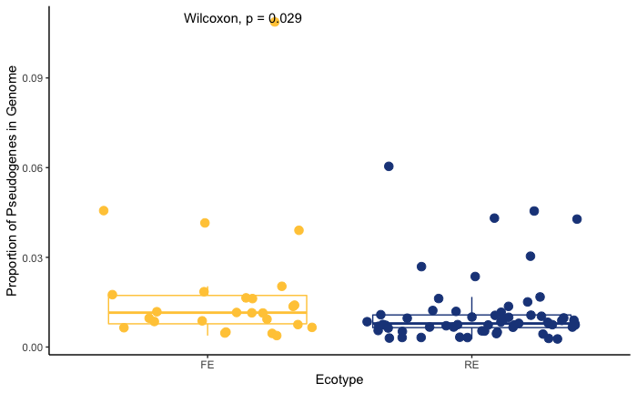

```r
#Figure 4E
#increased transposon activity could theoretically increase pseudogene count
psychrobacter_pseudogene_predictions = unique(psychrobacter_pseudogene_predictions)
pseudo_summary_by_genome = as.data.frame(table(psychrobacter_pseudogene_predictions$strainID))
colnames(pseudo_summary_by_genome) = c("strainID", "num_pseudo_candidates")
pseudo_summary_by_genome = left_join(pseudo_summary_by_genome, psych_strain_collection[,c(3,5)])
pseudo_summary_by_genome = left_join(pseudo_summary_by_genome, psychrobacter_genome_summaries[,c(1,6,13)])
pseudo_summary_by_genome$strainID = NULL
colnames(pseudo_summary_by_genome)[2] = "strainID"
pseudo_summary_by_genome = left_join(pseudo_summary_by_genome, ecotype)
pseudo_summary_by_genome$pseudo_proportion = pseudo_summary_by_genome$num_pseudo_candidates/pseudo_summary_by_genome$CDS.Number
dfast_pseudogenes = ggplot(data = pseudo_summary_by_genome, aes(x = ecotype, y = pseudo_proportion, color = ecotype)) +
  geom_point(position = 'jitter', size = 3) +
  geom_boxplot(alpha = 0, outlier.shape = NA) +
  scale_color_manual(values = c("#FFCA45", "#1F4589")) +
  theme_classic() +
  theme(legend.position = "none") +
  xlab("Ecotype") + ylab("Proportion of Pseudogenes in Genome") +
  stat_compare_means()
dfast_pseudogenes
```

```r
wilcox.test(pseudo_summary_by_genome$pseudo_proportion ~ pseudo_summary_by_genome$ecotype)
```

```
    Wilcoxon rank sum test with continuity correction

data:  pseudo_summary_by_genome$pseudo_proportion by pseudo_summary_by_genome$ecotype
W = 997, p-value = 0.02861
alternative hypothesis: true location shift is not equal to 0
```

```r
pseudo = as.vector(pseudo_summary_by_genome$pseudo_proportion)
names(pseudo) = pseudo_summary_by_genome$strainID
aov.phylo(formula = pseudo~eco, phy = multi2di(P.tree.noout))
```

```
Error in if (any(diag(m) < 0)) stop("'m' appears to have negative variance component(s)") :
  missing value where TRUE/FALSE needed
```

There is some concern about whether the predicted pseudogene number is related to genome assembly quality... it SHOULDN'T be, as DFAST removes sequences that do not end before the scaffold ends.

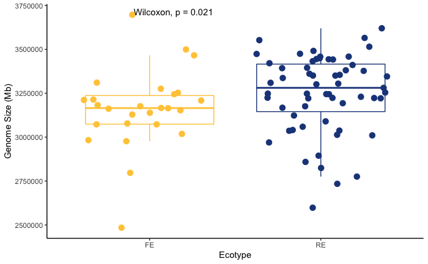

```r
#Figure 4F
#pseudogenes are expected to be quickly degraded, so you might expect genomes with more pseudogenes to be smaller.
colnames(psychrobacter_genome_summaries) = c("strainID", "Completeness", "Contamination", "Heterogeneity",
                          "GenomeLength", "Scaffolds", "N50Scaffolds", "MeanScaffoldLength",
                          "LongestScaffoldLength", "GC", "GCstdScaffolds", "CodingDensity",
                          "CDSNumber", "GeneNumber", "rRNANumber", "tRNANumber", "tmRNANumber",
                          "NumberofRepeatRegions", "ecotype_rev", "basal_derived", "source",
                          "source_type", "Location", "min_temp", "max_temp")
rownames(psychrobacter_genome_summaries) = psychrobacter_genome_summaries$strainID
psychrobacter_genome_summaries = left_join(psychrobacter_genome_summaries, psych_strain_collection[,c(3,5)])
psychrobacter_genome_summaries$strainID = NULL
colnames(psychrobacter_genome_summaries)[25] = 'strainID'
psychrobacter_genome_summaries = left_join(psychrobacter_genome_summaries, ecotype)
(genomesize = ggplot(data = psychrobacter_genome_summaries, aes(x = ecotype, y = GenomeLength, color = ecotype)) +
  geom_point(position = 'jitter', size = 3) +
  geom_boxplot(alpha = 0, outlier.shape = NA) +
  scale_color_manual(values = c("#FFCA45", "#1F4589")) +
  theme_classic() +
  theme(legend.position = "none") +
  xlab("Ecotype") + ylab("Genome Size (Mb)") +
  stat_compare_means())
```

```r
#check to make sure genome size isn't dependent on assembly quality
genomescaffoldmodel = lm(Scaffolds ~ GenomeLength, data = psychrobacter_genome_summaries)
summary(genomescaffoldmodel)
```

```
Call:
lm(formula = Scaffolds ~ GenomeLength, data = psychrobacter_genome_summaries)

Residuals:
    Min      1Q  Median      3Q     Max
-64.498 -42.302  -8.616  20.980 166.940

Coefficients:
              Estimate Std. Error t value Pr(>|t|)
(Intercept)  3.374e+01  8.073e+01   0.418    0.677
GenomeLength 8.592e-06  2.500e-05   0.344    0.732

Residual standard error: 51.4 on 83 degrees of freedom
Multiple R-squared:  0.001421,  Adjusted R-squared:  -0.01061
F-statistic: 0.1181 on 1 and 83 DF,  p-value: 0.732
```

```r
wilcox.test(psychrobacter_genome_summaries$GenomeLength ~ psychrobacter_genome_summaries$ecotype)
```

```
    Wilcoxon rank sum test with continuity correction

data:  psychrobacter_genome_summaries$GenomeLength by psychrobacter_genome_summaries$ecotype
W = 524, p-value = 0.02073
alternative hypothesis: true location shift is not equal to 0
```

```r
size = as.vector(psychrobacter_genome_summaries$GenomeLength)
names(size) = psychrobacter_genome_summaries$strainID
aov.phylo(formula = size~eco, phy = multi2di(P.tree.noout))
```

```
Error in if (any(diag(m) < 0)) stop("'m' appears to have negative variance component(s)") :
  missing value where TRUE/FALSE needed
```

# Figure 4

```
Removed 1 rows containing non-finite values (stat_boxplot).Removed 1 rows containing non-finite values (stat_compare_means).Removed 1 rows containing missing values (geom_point).
```

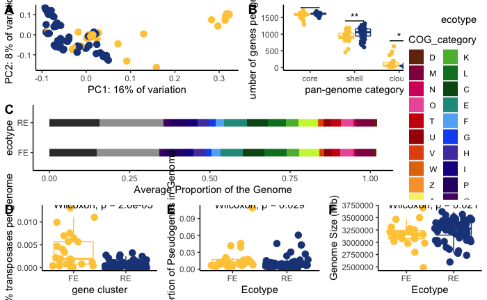

```r
ggarrange(ggarrange(gpa_pcoa_envfit, panstr, ncol = 2, labels = c("A", "B")),
          COGSbyecotype.p,
ggarrange(transposases,dfast_pseudogenes,genomesize, ncol = 3, labels = c("D", "E", "F")),
nrow = 3, labels = c("A", "C"))
```

```r
#ggarrange(mp,
#          ggarrange(count, temps, ncol = 2, labels = c("B", "C"), align = 'h'),
#          nrow = 2, heights = c(1.75, 1.2),
#          labels = "A")
```

# Animal Analysis

```r
setwd("~/ownCloud/Psychrobacter/Data_Analysis/PANX/masterfolder/Animal_Research/")
```

```
The working directory was changed to /Users/dwelter/ownCloud/Psychrobacter/Data_Analysis/PANX/masterfolder/Animal_Research inside a notebook chunk. The working directory will be reset when the chunk is finished running. Use the knitr root.dir option in the setup chunk to change the the working direc…
```

```r
polarbear_meta = read.delim("PB_metadata.txt", stringsAsFactors = F)
polarbear_otu_lvl7 = read.csv("PB_OTU_rarefied_level_7.csv", stringsAsFactors = F)
polarbear_otu_lvl6 = read.csv("PB_OTU_rarefied_level_6.csv", stringsAsFactors = F)
data = read.delim("biolog_totalchange.txt", header = TRUE, row.names = 1)
carbontypes = read.delim("carbonsourcetypes.txt", stringsAsFactors = F)
mouseboxplot = read.delim("cfu_counts_B6.txt")
```

The analysis involved in and generation of Figure 7A was done with Qiime 2 and Qiime View. Statistical testing was done in R.

```r
#Figure 7A
#analysis of Psychrobacter within the Qiime 2 OTU table
#check Psychrobacter (genus level) in captive v wild
polarbear_otu_lvl6$totalseqs = rowSums(polarbear_otu_lvl6[,2:849])
polarbear_otu_lvl6$Rel_Psych = polarbear_otu_lvl6$Psychrobacter/polarbear_otu_lvl6$totalseqs
lvl6 = polarbear_otu_lvl6 %>% select(SampleID, Rel_Psych)
lvl6 = left_join(lvl6, polarbear_meta)
lvl6 = unique(lvl6)
lvl6 = na.omit(lvl6)
wilcox.test(lvl6$Rel_Psych ~ lvl6$CaptivevWild, alternative = "two.sided") #ALMOST significant, but not with the sig figs that I am reporting
```

```
cannot compute exact p-value with ties
```

```
    Wilcoxon rank sum test with continuity correction

data:  lvl6$Rel_Psych by lvl6$CaptivevWild
W = 23.5, p-value = 0.04874
alternative hypothesis: true location shift is not equal to 0
```

```r
kruskal.test(Rel_Psych ~ diet_class, data = lvl6) #not significant at genus level
```

```
    Kruskal-Wallis rank sum test

data:  Rel_Psych by diet_class
Kruskal-Wallis chi-squared = 5.4352, df = 2, p-value = 0.06603
```

```r
kruskal.test(Rel_Psych ~ Location, data = lvl6) #sig at genus level
```

```
    Kruskal-Wallis rank sum test

data:  Rel_Psych by Location
Kruskal-Wallis chi-squared = 6.6127, df = 2, p-value = 0.03665
```

```r
kruskal.test(Rel_Psych ~ PBF.Year, data = lvl6) #sig at genus level
```

```
    Kruskal-Wallis rank sum test

data:  Rel_Psych by PBF.Year
Kruskal-Wallis chi-squared = 15.605, df = 5, p-value = 0.008066
```

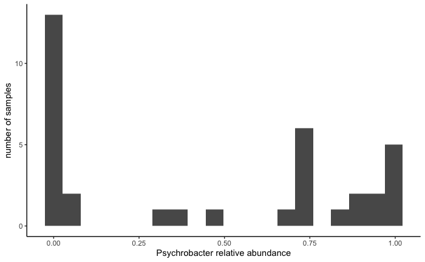

```r
(total_psych = ggplot(data = lvl6, aes(x = Rel_Psych)) + geom_histogram(bins = 20) +
    theme_classic() + xlab("Psychrobacter relative abundance") + ylab("number of samples"))
```

```r
#now looking at the species level
polarbear_otu_lvl7$totalseqs = rowSums(polarbear_otu_lvl7[,2:1585])
polarbear_otu_lvl7$Rel_unclassifiedPsych = polarbear_otu_lvl7$unclassified_Psychrobacter/polarbear_otu_lvl7$totalseqs
polarbear_otu_lvl7$Rel_pulmonis = polarbear_otu_lvl7$Psychrobacter_pulmonis/polarbear_otu_lvl7$totalseqs
polarbear_otu_lvl7$Rel_immobilis = polarbear_otu_lvl7$Psychrobacter_immobilis/polarbear_otu_lvl7$totalseqs
otu_selected = polarbear_otu_lvl7 %>%
  select(SampleID, Rel_unclassifiedPsych, Rel_pulmonis, Rel_immobilis)
otu_selected = left_join(otu_selected, polarbear_meta)
#testing individual spp. against captivity
wilcox.test(otu_selected$Rel_immobilis ~ otu_selected$CaptivevWild, alternative = "two.sided")
```

```
    Wilcoxon rank sum test with continuity correction

data:  otu_selected$Rel_immobilis by otu_selected$CaptivevWild
W = 277.5, p-value = 0.3015
alternative hypothesis: true location shift is not equal to 0
```

```r
wilcox.test(otu_selected$Rel_pulmonis ~ otu_selected$CaptivevWild, alternative = "two.sided")
```

```
    Wilcoxon rank sum test with continuity correction

data:  otu_selected$Rel_pulmonis by otu_selected$CaptivevWild
W = 443.5, p-value = 0.004092
alternative hypothesis: true location shift is not equal to 0
```

```r
wilcox.test(otu_selected$Rel_unclassifiedPsych ~ otu_selected$CaptivevWild, alternative = "two.sided")
```

```
    Wilcoxon rank sum test with continuity correction

data:  otu_selected$Rel_unclassifiedPsych by otu_selected$CaptivevWild
W = 222, p-value = 0.0799
alternative hypothesis: true location shift is not equal to 0
```

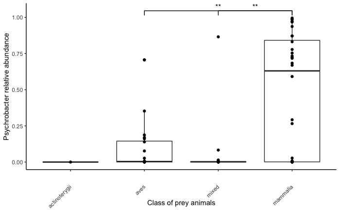

```r
#testing individual spp - unclassified
otu_selected_narm = otu_selected %>% filter(diet_class != "NA")
otu_selected_narm$diet_class = factor(otu_selected_narm$diet_class, levels = c("actinoterygii", "aves", "mixed", "mammalia"))
(diet = ggplot(data = otu_selected_narm, aes(x = diet_class, y = Rel_unclassifiedPsych)) + geom_boxplot(outlier.shape = NA) +
  geom_point() + theme_classic() +
        geom_signif(comparisons = list(c("mammalia", "mixed"), c("mammalia", "aves")), map_signif_level = T) +
    theme(axis.text.x = element_text(angle = 45, vjust = 0.5, hjust=1)) +
  xlab("Class of prey animals") + ylab("Psychrobacter relative abundance"))
```

```r
kruskal.test(Rel_unclassifiedPsych ~ Location, data = otu_selected)
```

```
    Kruskal-Wallis rank sum test

data:  Rel_unclassifiedPsych by Location
Kruskal-Wallis chi-squared = 18.616, df = 4, p-value = 0.0009348
```

```r
kruskal.test(Rel_unclassifiedPsych ~ PBF.Year, data = otu_selected)
```

```
    Kruskal-Wallis rank sum test

data:  Rel_unclassifiedPsych by PBF.Year
Kruskal-Wallis chi-squared = 16.561, df = 5, p-value = 0.005413
```

```r
kruskal.test(Rel_unclassifiedPsych ~ diet_class, data = otu_selected)
```

```
    Kruskal-Wallis rank sum test

data:  Rel_unclassifiedPsych by diet_class
Kruskal-Wallis chi-squared = 13.456, df = 3, p-value = 0.003747
```

```r
pairwise.wilcox.test(otu_selected$Rel_unclassifiedPsych, otu_selected$diet_class,
                     p.adjust.method = "BH")
```

```
cannot compute exact p-value with tiescannot compute exact p-value with tiescannot compute exact p-value with tiescannot compute exact p-value with tiescannot compute exact p-value with tiescannot compute exact p-value with ties
```

```
    Pairwise comparisons using Wilcoxon rank sum test

data:  otu_selected$Rel_unclassifiedPsych and otu_selected$diet_class

         actinoterygii aves  mammalia
aves     0.218         -     -
mammalia 0.218         0.028 -
mixed    0.218         0.218 0.028

P value adjustment method: BH
```

```r
#testing individual spp - immobilis
kruskal.test(Rel_immobilis ~ diet_class, data = otu_selected)
```

```
    Kruskal-Wallis rank sum test

data:  Rel_immobilis by diet_class
Kruskal-Wallis chi-squared = 1.9417, df = 3, p-value = 0.5846
```

```r
kruskal.test(Rel_immobilis ~ Location, data = otu_selected)
```

```
    Kruskal-Wallis rank sum test

data:  Rel_immobilis by Location
Kruskal-Wallis chi-squared = 2.9123, df = 4, p-value = 0.5726
```

```r
kruskal.test(Rel_immobilis ~ PBF.Year, data = otu_selected)
```

```
    Kruskal-Wallis rank sum test

data:  Rel_immobilis by PBF.Year
Kruskal-Wallis chi-squared = 10.121, df = 5, p-value = 0.07187
```

```r
#testing individual spp - pulmonis
kruskal.test(Rel_pulmonis ~ diet_class, data = otu_selected)
```

```
    Kruskal-Wallis rank sum test

data:  Rel_pulmonis by diet_class
Kruskal-Wallis chi-squared = 2.7646, df = 3, p-value = 0.4294
```

```r
kruskal.test(Rel_pulmonis ~ Location, data = otu_selected)
```

```
    Kruskal-Wallis rank sum test

data:  Rel_pulmonis by Location
Kruskal-Wallis chi-squared = 12.936, df = 4, p-value = 0.01159
```

```r
kruskal.test(Rel_pulmonis ~ PBF.Year, data = otu_selected)
```

```
    Kruskal-Wallis rank sum test

data:  Rel_pulmonis by PBF.Year
Kruskal-Wallis chi-squared = 7.3929, df = 5, p-value = 0.193
```

[figure not shown]

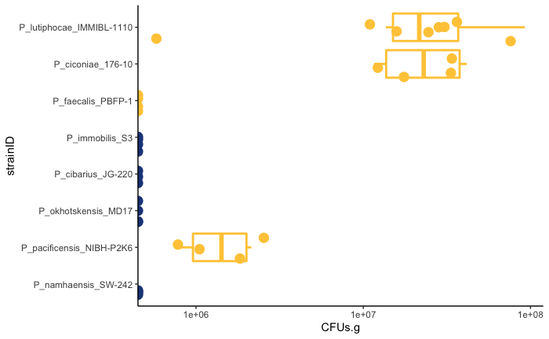

```r
#Figure 7 something
#the mouse work
#mouse tree visualized in iTol
mousestrains = c("P_namhaensis_SW-242","P_pacificensis_NIBH-P2K6","P_okhotskensis_MD17","P_cibarius_JG-220","P_immobilis_S3","P_faecalis_PBFP-1","P_ciconiae_176-10","P_lutiphocae_IMMIBL-1110")
                 #"immobilis_075", "cibarius_026", "okhotskensis_031")
mouse.tree.final = keep.tip(P.tree, mousestrains)
write.tree(mouse.tree.final, "mousestrainstree.nwk")
#####
#reorder strains so that they match the order of tips on the tree
mouseboxplot$propername = factor(mouseboxplot$propername,
                                 levels=c("P_namhaensis_SW-242","P_pacificensis_NIBH-P2K6","P_okhotskensis_MD17","P_cibarius_JG-220","P_immobilis_S3","P_faecalis_PBFP-1","P_ciconiae_176-10","P_lutiphocae_IMMIBL-1110"))
#average the duplicate aliquots tested
mouseboxplot2 = aggregate(mouseboxplot$CFUs.g, by = list(mouseboxplot$mouse, mouseboxplot$propername,
                                                         mouseboxplot$ecotype, mouseboxplot$isolation, mouseboxplot$Experiment), FUN = mean)
colnames(mouseboxplot2) = c("mouse", "strainID", "ecotype", "isolation", "Experiment", "CFUs.g")
#plot
ggplot(data = mouseboxplot2, aes(y = strainID, x = CFUs.g, color = ecotype)) +
  geom_boxplot(outlier.shape = NA, lwd = 1, alpha = 0) + geom_jitter(width = 0.1, size = 4) +
  scale_color_manual(values = c("#FFCA45", "#1F4589")) +
  scale_x_continuous(trans = 'log10') +
  theme_classic() +
  #stat_compare_means() +
  theme(legend.position = "none")
```

```r
kruskal.test(CFUs.g ~ strain, data = mouseboxplot)
```

```
    Kruskal-Wallis rank sum test

data:  CFUs.g by strain
Kruskal-Wallis chi-squared = 64.442, df = 7, p-value = 1.947e-11
```

```r
pairwise.wilcox.test(mouseboxplot$CFUs.g, mouseboxplot$strain, p.adjust.method = "BH")
```

[output not shown]

```
    Pairwise comparisons using Wilcoxon rank sum test

data:  mouseboxplot$CFUs.g and mouseboxplot$strain

                 cibarius_026 ciconiae_008 faecalis_023 immobilis_075 lutiphocae_013 namhaensis_029 okhotskensis_031
ciconiae_008     0.00168      -            -            -             -              -              -
faecalis_023     -            0.00053      -            -             -              -              -
immobilis_075    -            0.00053      -            -             -              -              -
lutiphocae_013   0.00053      0.74172      0.00034      0.00034       -              -              -
namhaensis_029   -            0.00053      -            -             0.00034        -              -
okhotskensis_031 -            0.00053      -            -             0.00034        -              -
pacificensis_032 0.00168      0.00053      0.00053      0.00053       0.00151        0.00053        0.00053

P value adjustment method: BH
```